# Análise de uma replicação

# Sobre Implicit Association Tests (IAT) – Olhe o README do repositório.

IAT: 0.15, 0.35, and 0.65 are considered small, medium, and large levels of bias for individual scores. Positive means bias towards arts / against Math.

# Exemplo de análise de uma replicação

```r
iat = read_csv(here::here(params$arquivo_dados), col_types = "cccdc")
iat = iat %>%
    mutate(sex = factor(sex, levels = c("m", "f"), ordered = TRUE))
glimpse(iat)
```

```
## Rows: 155
## Columns: 5
## $ session_id  <chr> "2436706", "2436967", "2440429", "2440430", "2440431", "24…
## $ referrer    <chr> "sdsu", "sdsu", "sdsu", "sdsu", "sdsu", "sdsu", "sdsu", "s…
## $ sex         <ord> f, f, f, f, m, f, f, m, f, m, f, f, f, f, f, f, m, m, f, m…
## $ d_art       <dbl> 0.90444320, -0.47402625, 0.46840862, -0.02522412, 0.136813…
## $ iat_exclude <chr> "Include", "Include", "Include", "Include", "Include", "In…
```

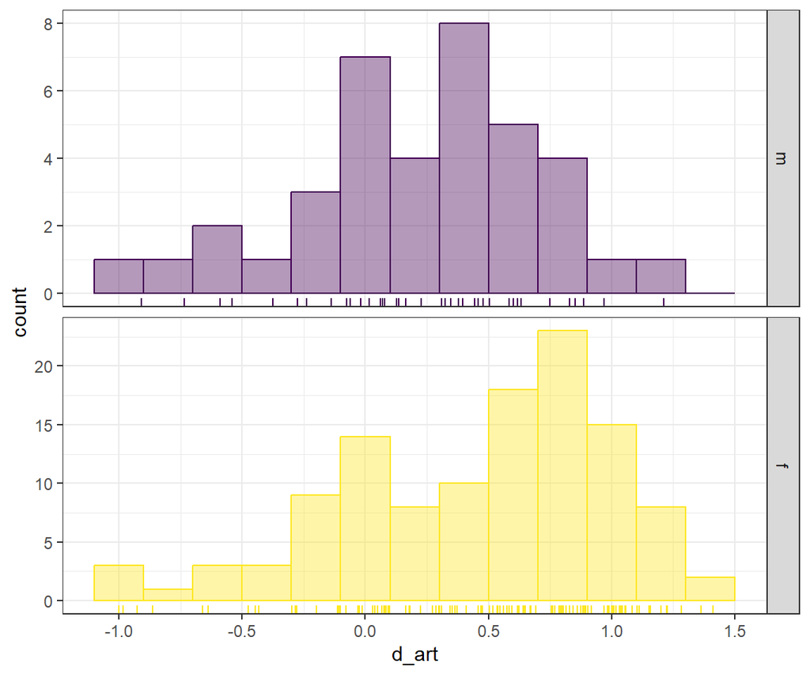

```r
iat %>%
    ggplot(aes(x = d_art, fill = sex, color = sex)) +
    geom_histogram(binwidth = .2, alpha = .4) +
    geom_rug() +
    facet_grid(sex ~ ., scales = "free_y") +
    theme(legend.position = "None")
```

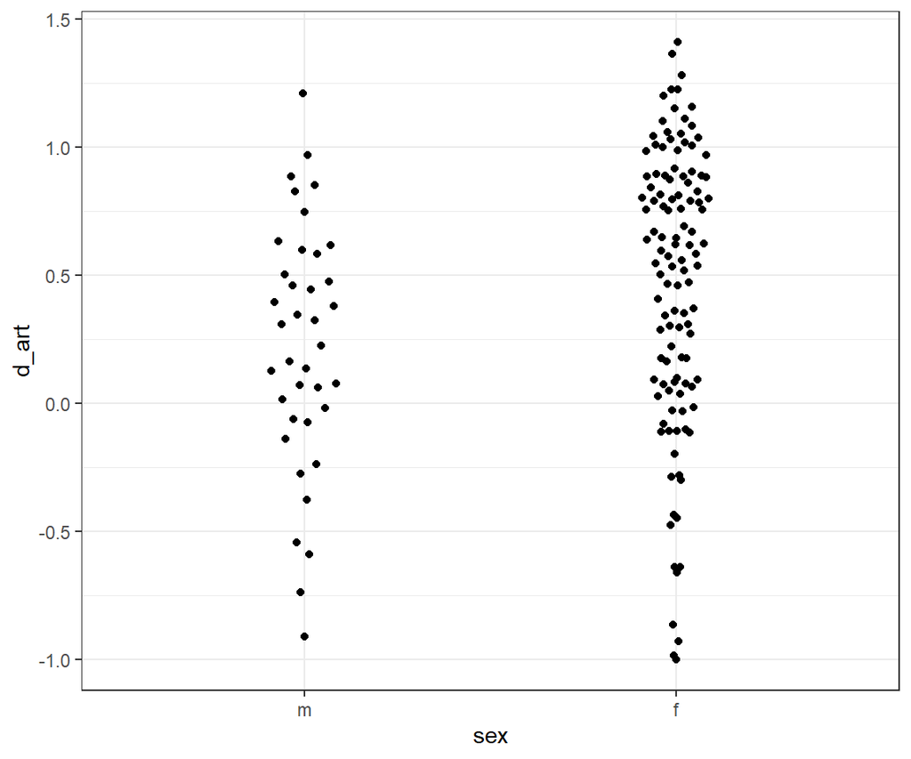

```r
iat %>%
    ggplot(aes(x = sex, y = d_art)) +
    geom_quasirandom(width = .1)
```

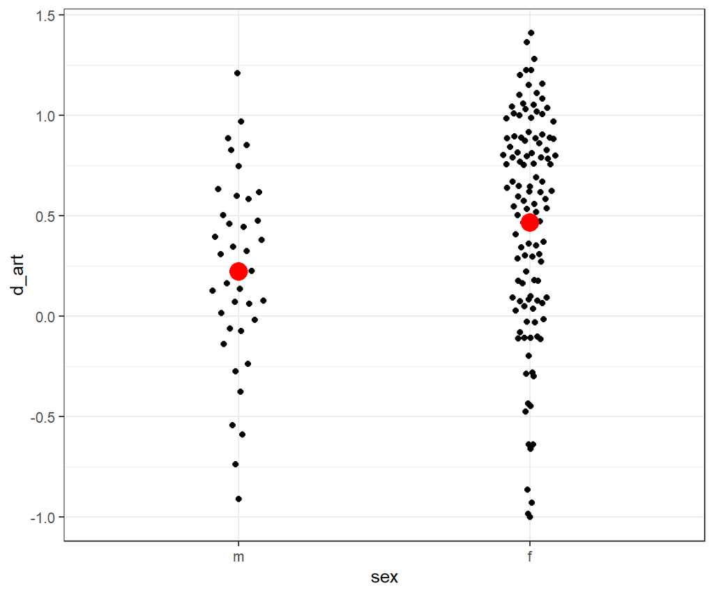

```r
iat %>%
    ggplot(aes(x = sex, y = d_art)) +
    geom_quasirandom(width = .1) +
    stat_summary(geom = "point", fun.y = "mean", color = "red", size = 5)
```

##### Qual a diferença na amostra

```r
iat %>%
    group_by(sex) %>%
    summarise(media = mean(d_art))
```

```
## # A tibble: 2 × 2
##   sex   media
##   <ord> <dbl>
## 1 m     0.224
## 2 f     0.467
```

```r
agrupado = iat %>%
        group_by(sex) %>%
        summarise(media = mean(d_art))
    m = agrupado %>% filter(sex == "m") %>% pull(media)
    f = agrupado %>% filter(sex == "f") %>% pull(media)
m - f
```

```
## [1] -0.2430539
```